# Estimation of subnational fertility in SSA

Oli Stevens

2019-07-24

## Load packages

```r
library(tidyverse)
library(rdhs)
library(demogsurv)
library(INLA)
library(reshape2)
```

## Calculate ASFR, TFR

```r
surveys <- dhs_surveys(countryIds = "MW", surveyYearStart=1995)
```

[output not shown]

```r
ird <- dhs_datasets(fileType = "IR", fileFormat = "flat", surveyIds = surveys$SurveyId)
ird$path <- unlist(get_datasets(ird))
```

```
#> Logging into DHS website...
#> Creating Download url list from DHS website...
#> Some of your available datasets are not found in the DHS API.This is likely due to the DHS API being out of date and as such some of the meta information about your available datasets may not be available.
```

```r
ir <- lapply(ird$path, readRDS) %>%
  Map(data.frame,
      surveyid = surveys$SurveyId,
      country = surveys$CountryName,
      survyear = surveys$SurveyYear,
      survtype = surveys$SurveyType,
      .,
      stringsAsFactors = FALSE)

tips_surv <- list("DHS" = c(0, 7), "MIS" = c(0, 5))[surveys$SurveyType]

tfr <- Map(calc_tfr, ir,
           by = list(~surveyid + country + survyear + v025),
           tips = tips_surv,
           period = list(1995:2017))

tfr <- tfr %>%
  bind_rows %>%
  type.convert %>%
  mutate(v025 = factor(v025, levels= c(1,2), labels = c("Urban", "Rural"))) %>%
  filter(period <= survyear) %>%
  mutate(lower = tfr - qnorm(0.975) * se_tfr,
         upper = tfr + qnorm(0.975) * se_tfr)

asfr <- Map(calc_asfr, ir,
            by = list(~surveyid + country + survyear+ v025),
            tips = tips_surv,
            period = list(1995:2017),
            counts = TRUE)
```

## Create id indicies for age, period, and age.period.

```r
asfr1 <- asfr %>%
  bind_rows %>%
  type.convert %>%
  mutate(v025 = factor(v025, levels= c(1,2), labels = c("Urban", "Rural"))) %>%
  filter(period <= survyear) %>%
  mutate(id.period = group_indices(., period),
         id.period2 = id.period,
         id.agegr = group_indices(., agegr),
         id.agegr2 = id.agegr,
         id.agegr.period = group_indices(., period, agegr),
         id = 1:nrow(.))
```

# Models

## Age as iid

```r
formula.1 <- births ~ v025 + period + f(id.agegr, model="iid")

mod <- inla(formula.1, family="poisson", data=asfr_pred, offset=log(pys),
            control.family=list(link='log'),
            control.predictor=list(compute=TRUE, link=1),
            control.compute=list(config = TRUE, dic= TRUE, cpo=TRUE))
summary(mod)
```

```
#>
#> Call:
#> c("inla(formula = formula.1, family = \"poisson\", data = asfr_pred, ",  "    offset = log(pys), control.compute = list(config = TRUE, ",  "        dic = TRUE, cpo = TRUE), control.predictor = list(compute = TRUE, ",  "        link = 1), control.family = list(link = \"log\"))")
#>
#> Time used:
#>  Pre-processing    Running inla Post-processing           Total
#>          1.3625          0.5048          0.1567          2.0240
#>
#> Fixed effects:
#>                mean     sd 0.025quant 0.5quant 0.975quant    mode kld
#> (Intercept) 27.3281 1.2085    24.9546  27.3283    29.6985 27.3288   0
#> v025Rural    0.3691 0.0099     0.3497   0.3691     0.3886  0.3691   0
#> period      -0.0148 0.0006    -0.0159  -0.0148    -0.0136 -0.0148   0
#>
#> Random effects:
#> Name   Model
#>  id.agegr   IID model
#>
#> Model hyperparameters:
#>                         mean    sd 0.025quant 0.5quant 0.975quant  mode
#> Precision for id.agegr 2.529 1.245     0.6955    2.326      5.492 1.903
#>
#> Expected number of effective parameters(std dev): 9.511(0.0034)
#> Number of equivalent replicates : 67.71
#>
#> Deviance Information Criterion (DIC) ...............: 3108.56
#> Deviance Information Criterion (DIC, saturated) ....: 2021.44
#> Effective number of parameters .....................: 9.525
#>
#> Marginal log-Likelihood:  -1606.45
#> CPO and PIT are computed
#>
#> Posterior marginals for linear predictor and fitted values computed
```

Posterior distribution from age group random effect

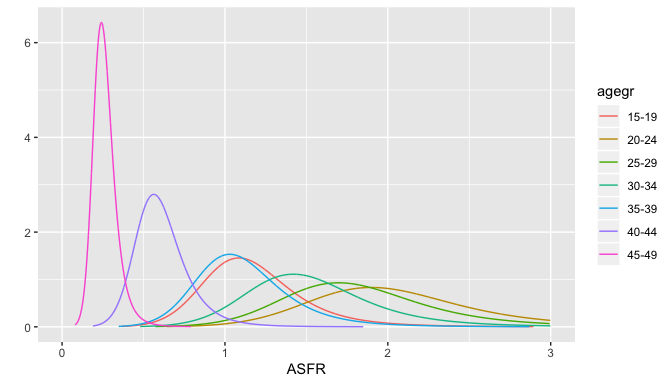

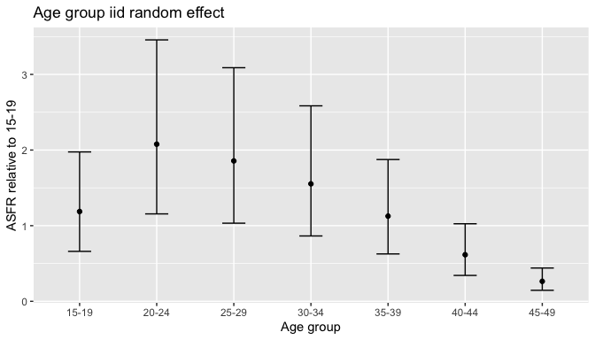

## Comparing models

(Matt recommended a 1st order random walk on age if only 7 groups, but a 2nd order random walk with 22 years)

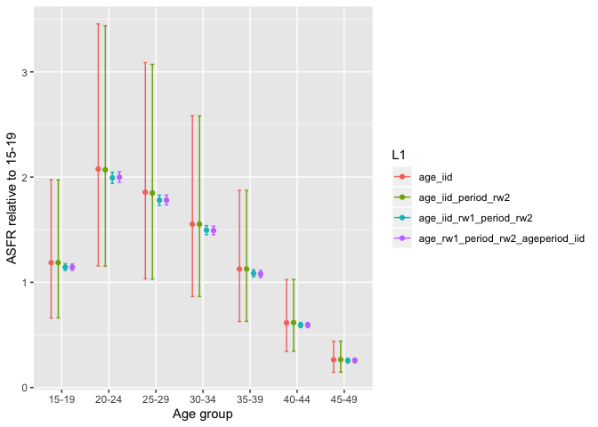

```r
formula.2 <- births ~ v025 + period + f(id.agegr, model="iid")
formula.3 <- births ~ v025 + f(id.period, model="rw2") + f(id.agegr, model="iid")
formula.4 <- births ~ v025 + f(id.period, model="rw2") + f(id.agegr2, model="iid") + f(id.agegr, model="rw1")
formula.5 <- births ~ v025 + f(id.period, model="rw2") + f(id.agegr.period, model="iid") + f(id.agegr, model="rw1")

form_list <- list(formula.2, formula.3, formula.4, formula.5)
names(form_list) <- c("age_iid", "age_iid_period_rw2", "age_iid_rw1_period_rw2", "age_rw1_period_rw2_ageperiod_iid")
```

## Append prediction dataframe (NA for births, pys=1)

```r
asfr_pred <- asfr %>%
  bind_rows %>%
  type.convert %>%
  mutate(v025 = factor(v025, levels= c(1,2), labels = c("Urban", "Rural"))) %>%
  filter(period <= survyear) %>%
  mutate(births = NA_integer_,
         pys = 1,
         asfr = NA_integer_,
         se_asfr = NA_integer_)%>%
  select("v025", "agegr", "period", "pys") %>%
  group_by_all() %>%
  summarise() %>%
  ungroup() %>%
  bind_rows(asfr %>%
              bind_rows %>%
              type.convert %>%
              mutate(v025 = factor(v025, levels= c(1,2), labels = c("Urban", "Rural"))) %>%
              filter(period <= survyear)) %>%
  mutate(id.period = group_indices(., period),
         id.agegr = group_indices(., agegr),
         id.agegr.period = group_indices(., period, agegr),
         id = 1:nrow(.))

head(asfr_pred %>%
       select("v025", "agegr", "period", "births", "pys", "id.agegr", "id.period", "id.agegr.period", "id"))
```

```
#> # A tibble: 6 x 9
#>   v025  agegr period births   pys id.agegr id.period id.agegr.period    id
#>   <fct> <fct>  <int>  <dbl> <dbl>    <int>     <int>           <int> <int>
#> 1 Urban 15-19   1995     NA     1        1         1               1     1
#> 2 Urban 15-19   1996     NA     1        1         2               8     2
#> 3 Urban 15-19   1997     NA     1        1         3              15     3
#> 4 Urban 15-19   1998     NA     1        1         4              22     4
#> 5 Urban 15-19   1999     NA     1        1         5              29     5
#> 6 Urban 15-19   2000     NA     1        1         6              36     6
```

## Run model 5 with prediction data frame

Don’t yet understand this output. I think this should provide estimates of ASFR for a given single person year. Rural is higher than urban, and the age groups are in the correct relative order, but the outcome is far too high. Is `control.predictor=list(compute=TRUE, link=1)` correct?

```r
mod <- inla(formula.5, family="poisson", data=asfr_pred, offset=log(pys),
                control.family=list(link='log'),
                control.predictor=list(compute=TRUE, link=1),
                control.compute=list(config = TRUE, dic= TRUE, cpo=TRUE))

summary(mod)
```

```
#>
#> Call:
#> c("inla(formula = formula.5, family = \"poisson\", data = asfr_pred, ",  "    offset = log(pys), control.compute = list(config = TRUE, ",  "        dic = TRUE, cpo = TRUE), control.predictor = list(compute = TRUE, ",  "        link = 1), control.family = list(link = \"log\"))")
#>
#> Time used:
#>  Pre-processing    Running inla Post-processing           Total
#>          1.7289          0.6922          0.1574          2.5785
#>
#> Fixed effects:
#>                mean     sd 0.025quant 0.5quant 0.975quant    mode kld
#> (Intercept) -2.3289 0.0125    -2.3536  -2.3289    -2.3044 -2.3288   0
#> v025Rural    0.3702 0.0099     0.3508   0.3702     0.3897  0.3702   0
#>
#> Random effects:
#> Name   Model
#>  id.period   RW2 model
#> id.agegr.period   IID model
#> id.agegr   RW1 model
#>
#> Model hyperparameters:
#>                                  mean      sd 0.025quant 0.5quant 0.975quant    mode
#> Precision for id.period       148.922  79.986     51.982   130.09     354.45 101.307
#> Precision for id.agegr.period 650.472 233.087    315.599   609.80    1219.32 537.500
#> Precision for id.agegr          5.194   2.621      1.594     4.72      11.63   3.717
#>
#> Expected number of effective parameters(std dev): 73.64(7.705)
#> Number of equivalent replicates : 8.745
#>
#> Deviance Information Criterion (DIC) ...............: 2442.32
#> Deviance Information Criterion (DIC, saturated) ....: 1355.20
#> Effective number of parameters .....................: 75.20
#>
#> Marginal log-Likelihood:  -1309.50
#> CPO and PIT are computed
#>
#> Posterior marginals for linear predictor and fitted values computed
```

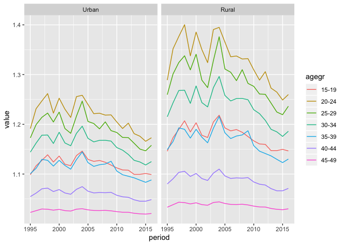

```r
asfr_pred %>%
  filter(id<309) %>%
  select("v025", "agegr", "period","pys", "id") %>%
  left_join(mod$marginals.fitted.values[1:308] %>%
              lapply(t_emarg) %>%
              melt() %>%
              mutate(id = 1:308), by="id") %>%
  arrange(period, v025, agegr) %>%
  ggplot(aes(x=period, y=value, group=agegr))+
  geom_line(aes(color=agegr)) +
  facet_wrap(~v025)
```

## Plotting id.agegrp.period iid random effect

Bit of a mess - also not sure about this. This should allow an interaction between age group and period & give discernable trends? Matt wondered whether this was overfitting.

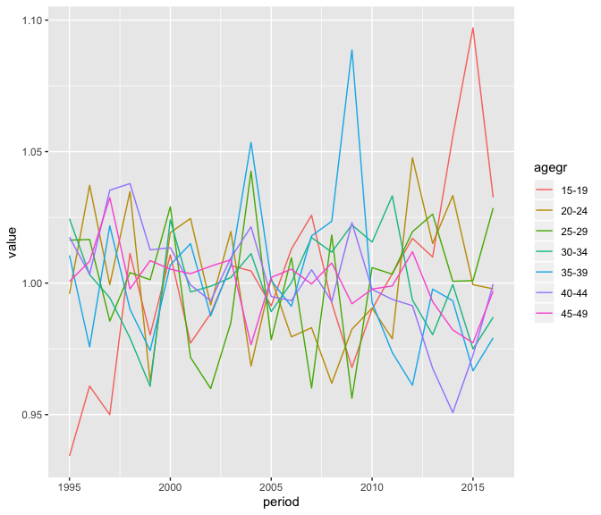

## Comparing RW1 with RW2 on period

`births ~ v025 + f(id.agegr, model="rw1") + f(id.period, model="rw1") + f(id.agegr.period, model="iid")`

`births ~ v025 + f(id.agegr, model="rw1") + f(id.period, model="rw2") + f(id.agegr.period, model="iid")`

Very similar - is this because of the amount of data dominating the prior?

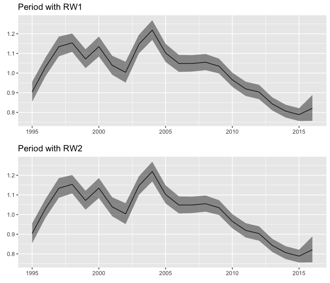